# Why use R?

## Course contents & materials

The complete source code for the webinars and all dependent data, and files can be found on [Github.com/uashogeschoolutrecht/](https://github.com/uashogeschoolutrecht/staRters).

- Day 1: Why R, Case demo, RMarkdown, Intro R syntax
- Day 2: Visualization, Data Wrangling, Tidy data
- Day 3: Data import, Statistics (assumptions & regression)

*Disclaimer: “This is not a course on statistics”. If you have a specific statistical challenge and you would like to discuss this after the course with me, feel invited to reach out!*

## Introducing Reproducible (Open) Science

1. When things go wrong
2. Why Reproducible (Open) Science?
3. The need for learning programming
4. An example of Reproducible (Open) Science

\(Reproducible\ (Open)\ Science =\) \(Reproducible\ Research + Open\ Science\)

## Data, methods and logic

*[Brown, Kaiser & Allison, PNAS, 2018](https://doi.org/10.1073/pnas.1708279115)*

"…in science, three things matter:

1. the data,
2. the methods used to collect the data […], and
3. **the logic connecting the data and methods to conclusions,**

everything else is a distraction."

## `Gollums` lurking about

[figure not shown]

“In one case, a group accidentally used reverse-coded variables, making their conclusions the opposite of what the data supported.”

“In another case, authors received an incomplete dataset because entire categories of data were missed; when corrected, the qualitative conclusions did not change, but the quantitative conclusions changed by a factor of >7”

[Brown, Kaiser & Allison, 2018; PNAS](https://doi.org/10.1073/pnas.1708279115)

## Why we need Reproducible (Open) Science?

- To assess validity of science and methods we need access to data, methods and conclusions
- To learn from choices other researchers made
- To learn from omissions, mistakes or errors
- To prevent publication bias (also negative results will be available in reproducible research)
- To be able to re-use and/or synthesize data (from many and diverse sources)
- To have access to it all!

[Nature Collection on this topic](https://www.nature.com/collections/prbfkwmwvz)

## The *GUI problem*

How would you ‘describe’ the steps of an analysis or creation of a graph when you use *GUI* based software?

*“You can only do this using code, so it is (basically) impossible in a GUI”*

[figure not shown]

*[Graphical User Interface (GUI)…is a form of user interface that allows users to interact with electronic devices through graphical icons and audio indicator such as primary notation, instead of text-based user interfaces, typed command labels or text navigation…](https://en.wikipedia.org/wiki/Graphical_user_interface)

## Programming is essential for Reproducible (Open) Science

- Only programming an analysis (or creation of a graph) records every step
- The script(s) function as a (data) analysis journal
- Code is the logic that connects the data and methods to conclusions
- Learning to use a programming language takes time but pays of at the long run (for all of science)

## Introducing Literate programming

- Literate) programming is a way to connect narratives to data, methods and results
- All scripts in this course are **R Markdown** scripts
- The complete source of the reader is available in Github.com

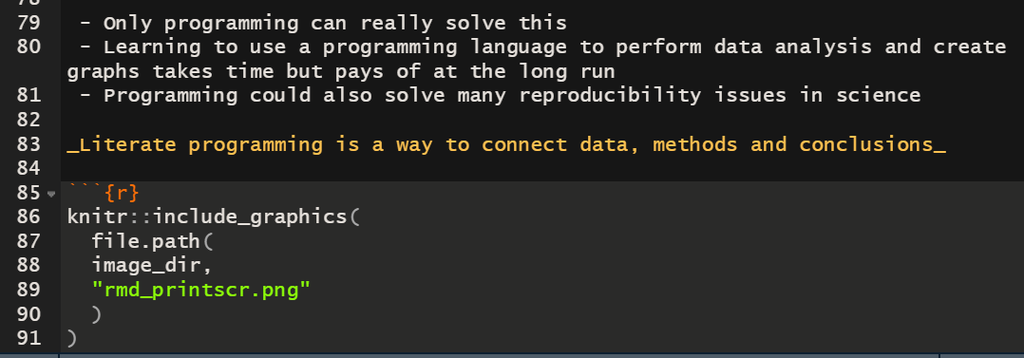

## To replicate a scientific study we need at least:

- Scientific context, research questions and state of the art [P]
- (Experimental) model or characteristics of population or matter studied [P]
- Data that was generated and corresponding meta data [D, *C*]
- **Exact** (experimental) design of the study [P, *D*, C]
- Exploratory data analysis of the data [*P*, C]
- **Exact** methods that were used to conduct any formal inference [*P*, C]
- Model diagnostics [*C*]
- Interpretations of the (statistical) model results/model fitting process [*P*, *C*]
- Conclusions and academic scoping of the results [P, *C*]
- **Access to all of the above** [OAcc, OSrc]

\(P = Publication\), \(D = Data\), \(C = Code\), \(OAcc = Open\ Access\), \(OSrc = Open\ Source\)

## Why R?

- R is free
- R has a huge user-community
- R has many packages
- Many statistical applications (more than SPSS)
- R connects to other tools
- R has RStudio as an IDE
- You can find (almost) every example you want on the internet
- R has superb plotting possibilities …

## A short example of Reproducible (Open) Science

Assume we have the following question: “Which of 4 types of chairs takes the least effort to arise from when seated in?” We have the following setup:

- 4 different types of chairs
- 9 different subjects (probably somewhat aged)
- Each subject is required to provide a score (from 6 to 20, 6 being very lightly strenuous, 20 being extremely strenuous) when arising from each of the 4 chairs. There is some ‘wash-out’ time in between the trials. The chair order is randomised.

To analyze this experiment statistically, the model would need to include: the rating score as the **measured (or dependent) variable**, the type of chair as the **experimental factor** and the subject as the **blocking factor**

## Now we move to RStudio

- If you have 2 screens, now is the moment to expand the screen
- Login to your Rstudio Environment
- Clone the materials of the course to your `Home` folder
- You can find the steps also in `_gettingstarted.Rmd`
- Open the file `_why_r.Rmd`
- Follow along the demo by running the code
- Details on using RStudio can be found in `_introrstudio`

## Mixed effects models

A typical analysis method for this type of randomized block design is a so-called ‘multi-level’ or also called ‘mixed-effects’ or ‘hierarchical’ models. An analysis method much used in clinical or biological scientific practice.

## What do we minimally need, to replicate the science of this experiment?

I will show:

- the data
- an exploratory graph
- a statistical model
- the statistical model results
- a model diagnostic
- some conclusions

In the next few slides, I will hopefully convince you of the power of (literate) programming to communicate such an analysis.

[Example reproduced from: Pinheiro and Bates, 2000, *Mixed-Effects Models in S and S-PLUS*, Springer, New York.](https://cran.r-project.org/web/packages/nlme/index.html)

## The data of the experiment

[Wretenberg, Arborelius & Lindberg, 1993](https://doi.org/10.1080/00140139308967910)

```r
library(nlme)
ergoStool %>% as_tibble()
```

```
## # A tibble: 36 x 3
##    effort Type  Subject
##     <dbl> <fct> <ord>
##  1     12 T1    1
##  2     15 T2    1
##  3     12 T3    1
##  4     10 T4    1
##  5     10 T1    2
##  6     14 T2    2
##  7     13 T3    2
##  8     12 T4    2
##  9      7 T1    3
## 10     14 T2    3
## # ... with 26 more rows
```

## An exploratory graph

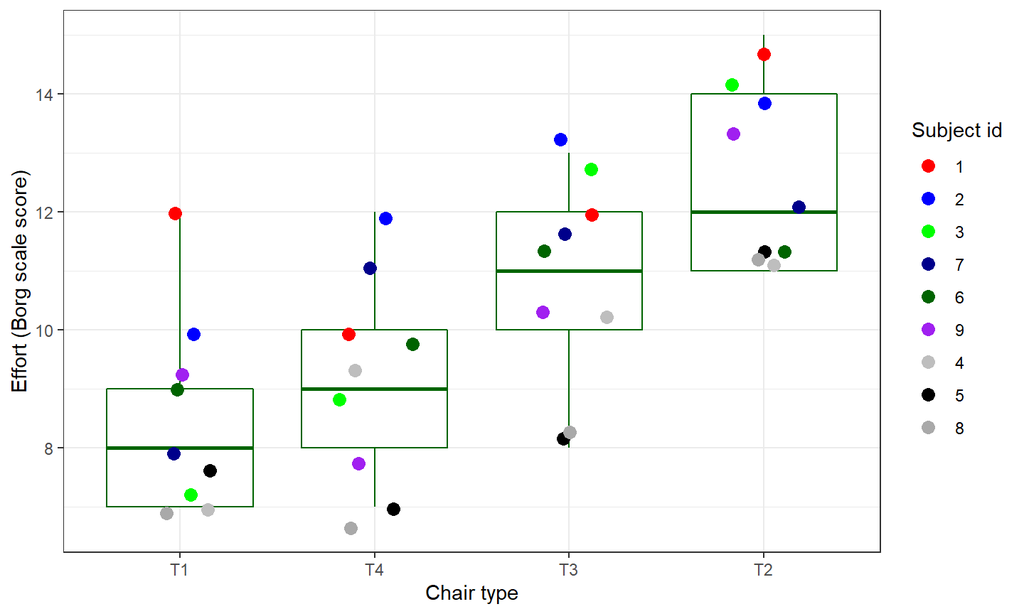

## Mind the variability per subject, what do you see?

- Can you say something about within-subject variability (note ‘Minster Blue’)?
- Can you say something about between-subject variability (note ‘Mister Green’, vs ‘Mister Black’)?
- Which chair type takes, on average the biggest effort to arise from?

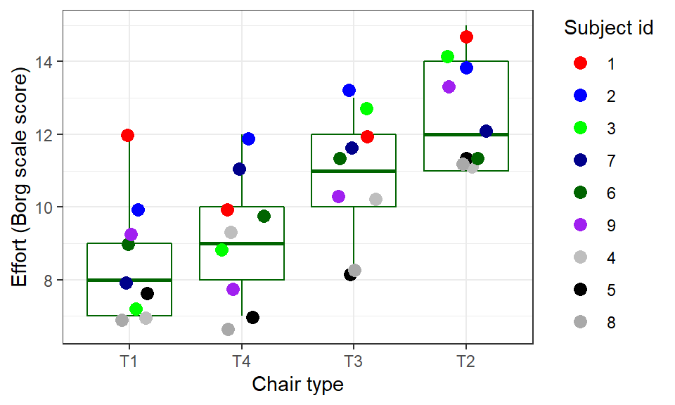

## The statistical questions

1. Which chair type takes, on average the biggest effort to arise from? (ANOVA / MEM, fixed effects)
- Do individual (within subject) differences play a role in appointing a average score to a chair type? (MEM, random effects)
- Does variability between subjects play a role in determining the ‘best’ chair type (ANOVA / MEM, confidence intervals)

## The statistical model

Statistical models (in R) can be specified by a `model formula`. The left side of the formula is the dependent variable, the right side are the ‘predictors’. Here we include a `fixed` and a `random` term to the model (as is common for mixed-effects models)

```r
library(nlme)
```

```r
ergo_model <- lme(
  data = ergoStool, # the data to be used for the model
  fixed = effort ~ Type, # the dependent and fixed effects variables
  random = ~1 | Subject # random intercepts for Subject variable
)
```

The `lme()` function is part of the [`{nlme}`](https://cran.r-project.org/web/packages/nlme/index.html) package for mixed effects modelling in R

Example reproduced from: [Pinheiro and Bates, 2000, *Mixed-Effects Models in S and S-PLUS*, Springer, New York.](https://cran.r-project.org/web/packages/nlme/index.html)

## The statistical results

|  | Value | Std.Error | DF | t-value | p-value |
| --- | --- | --- | --- | --- | --- |
| (Intercept) | 8.5555556 | 0.5760123 | 24 | 14.853079 | 0.0000000 |
| TypeT2 | 3.8888889 | 0.5186838 | 24 | 7.497610 | 0.0000001 |
| TypeT3 | 2.2222222 | 0.5186838 | 24 | 4.284348 | 0.0002563 |
| TypeT4 | 0.6666667 | 0.5186838 | 24 | 1.285305 | 0.2109512 |

## Model diagnostics

- Diagnostics of a fitted model is the most important step in a statistical analysis
- In most scientific papers the details are lacking
- Did the authors omit to perform this step? Or did they not report it?
- If you do not want to include it in your paper, put it in an appendix!

## Residuals

A residual plot shows the ‘residual’ error (‘unexplained variance’) after fitting the model. Under the Normality assumption standardized residuals should:

1. Be normally distributed around 0
2. Display no obvious ‘patters’
3. Should display overall equal ‘spread’ above and below 0 (‘assumption of equal variance’)

## Residual plot

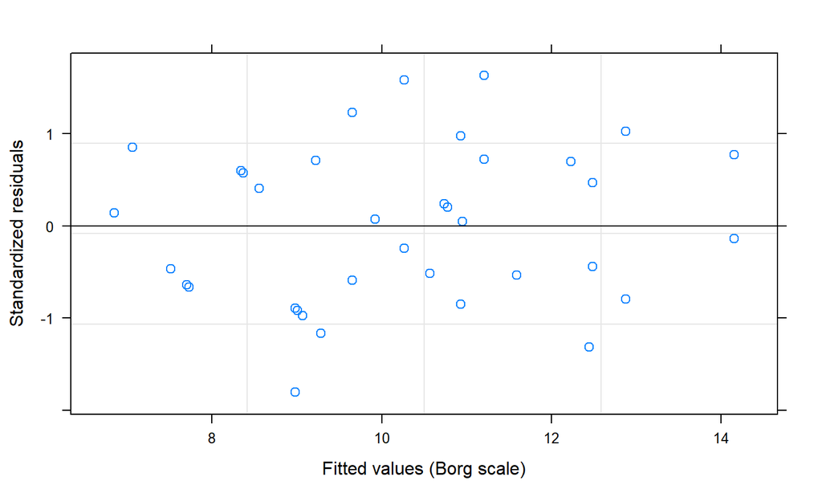

```r
plot(ergo_model) ## type = 'pearson' (standardized residuals)
```

## The conclusions in a plot

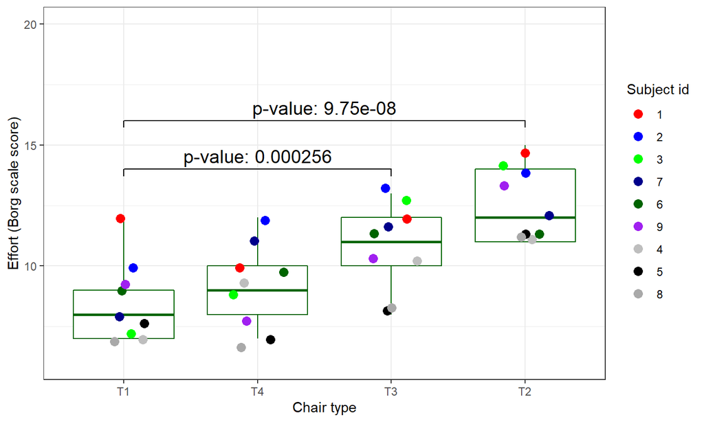

## And the most important part…

– Coffee break –